# Vignette moveNT

Guillaume Bastille-Rousseau

April 18, 2017

# Simulating movement strategies - *sim_mov*

The function *sim_mov* generates movement trajectories including patches and movement between patches. Movement within patches can follow an Ornstein-Uhlenbeck process (based on *simm.mou* function from package *adehabitatLT*) or two-states movement model (based on *simmData* function from package *moveHMM*). Movement between patches is following a brownian bridge movement model (based on *simm.bb* function from package *adehabitatLT*). Generated outputs are of the class *ltraj* from package *adehabitatlt*.

```r
# Simulating migration with two-states model
mig<-sim_mov(type="2states", npatches=2, ratio=2, nswitch=25, ncore=150, grph=F)
mig
```

```
##
## *********** List of class ltraj ***********
##
## Type of the traject: Type II (time recorded)
## * Time zone: GMT *
## Regular traject. Time lag between two locs: 1 seconds
##
## Characteristics of the bursts:
##   id burst nb.reloc NAs          date.begin            date.end
## 1 id    id     4350   0 1960-01-01 00:00:01 1960-01-01 01:12:30
##
##
##  infolocs provided. The following variables are available:
## [1] "out.Corri"
```

```r
head(ld(mig))
```

```
##          x        y                date           dx           dy
## 1 400.0000 800.0000 1960-01-01 00:00:01  7.195756102  4.312777052
## 2 407.1958 804.3128 1960-01-01 00:00:02  0.065397243  0.048839618
## 3 407.2612 804.3616 1960-01-01 00:00:03  0.002905396 -0.001803554
## 4 407.2641 804.3598 1960-01-01 00:00:04 -0.667679396  8.502626909
## 5 406.5964 812.8624 1960-01-01 00:00:05  0.002702666  0.003375255
## 6 406.5991 812.8658 1960-01-01 00:00:06  1.316584482  2.763374308
##          dist dt       R2n  abs.angle  rel.angle id burst out.Corri
## 1 8.389216398  1   0.00000  0.5399415         NA id    id         2
## 2 0.081621735  1  70.37895  0.6414594  0.1015179 id    id         2
## 3 0.003419669  1  71.74805 -0.5555446 -1.1970039 id    id         2
## 4 8.528801799  1  71.77452  1.6491618  2.2047063 id    id         2
## 5 0.004323974  1 208.95458  0.8956107 -0.7535510 id    id         2
## 6 3.060985505  1 209.07709  1.1261730  0.2305623 id    id         2
```

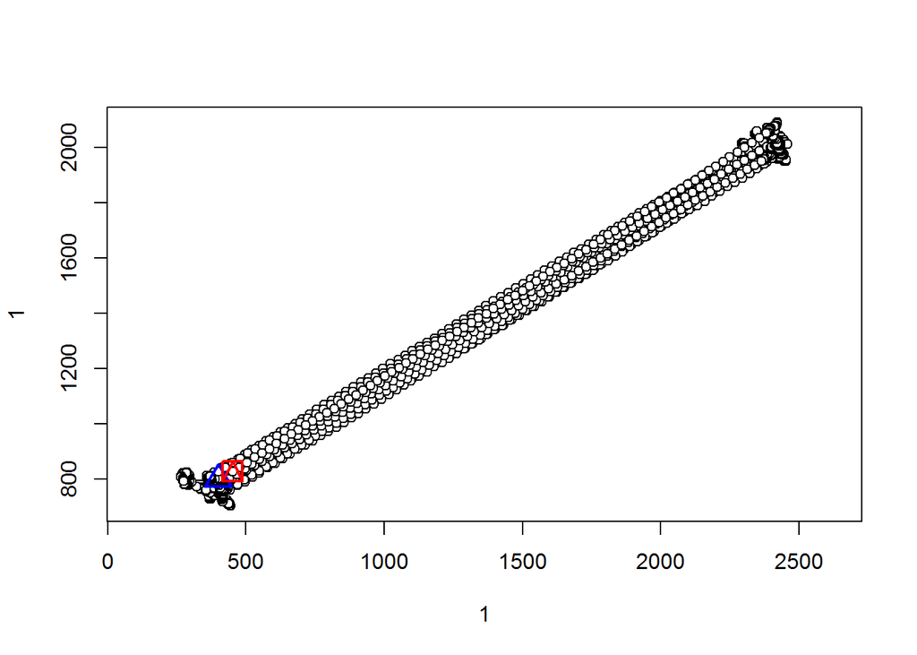

```r
plot(mig)
```

```r
# Simulating multi-patches movement with Ornstein-Uhlenbeck process
patches<-sim_mov(nswitch=25, ncore=150, ratio=5, type="OU", npatches=5, grph=T)
```

[figure not shown]

```r
# Simulating sedentary movement
seden<-sim_mov(type="OU", npatches=10, spacecore=12, ratio=3, nswitch=150, ncore=20, grph=T)
```

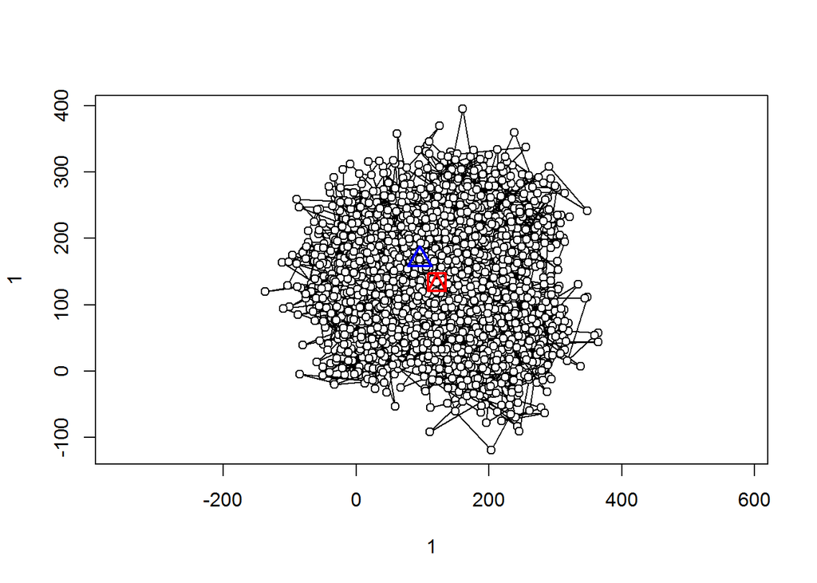

# Converting movement to adjacency matrix - *traj2adj*

The function *traj2adj* converts a trajectory object of class *ltraj* to an adjacency matrix. This is done by overlapping a grid over the relocation data and tallying the number of transitions among each pixel. Users need to specify the grid size, which can be based on distance travelled. The function *quant* is a wrapper that allows to sample a quantile of step length distribution from a *ltraj* object. Output produced by *traj2adj* is a list containing the adjacency matrix, the grid used (raster format), and a raster indicating pixel numbers that are occupied. These rasters are used by other functions such as *adj2stack* and *clustnet*.

```r
# Using sedentary movement and user specific grid-size
adj_seden<-traj2adj(seden, res=150) #Pixel size of 150m
adj_seden[[1]] # Adjency matrix
```

```
##       [,1] [,2] [,3] [,4] [,5] [,6] [,7] [,8] [,9]
##  [1,]    9    8    0    3    2    0    0    0    0
##  [2,]    4   84   13    3   72    9    0    0    0
##  [3,]    0   14   59    0   14   41    0    0    0
##  [4,]    7    6    0  220   94    0   21    9    0
##  [5,]    2   60   22   94  858   88   13  107   21
##  [6,]    0   13   34    0   83  323    0   12   55
##  [7,]    0    0    0   22   13    0   48   37    0
##  [8,]    0    0    0   15  106    4   38  346   68
##  [9,]    0    0    0    0   23   54    0   64  415
```

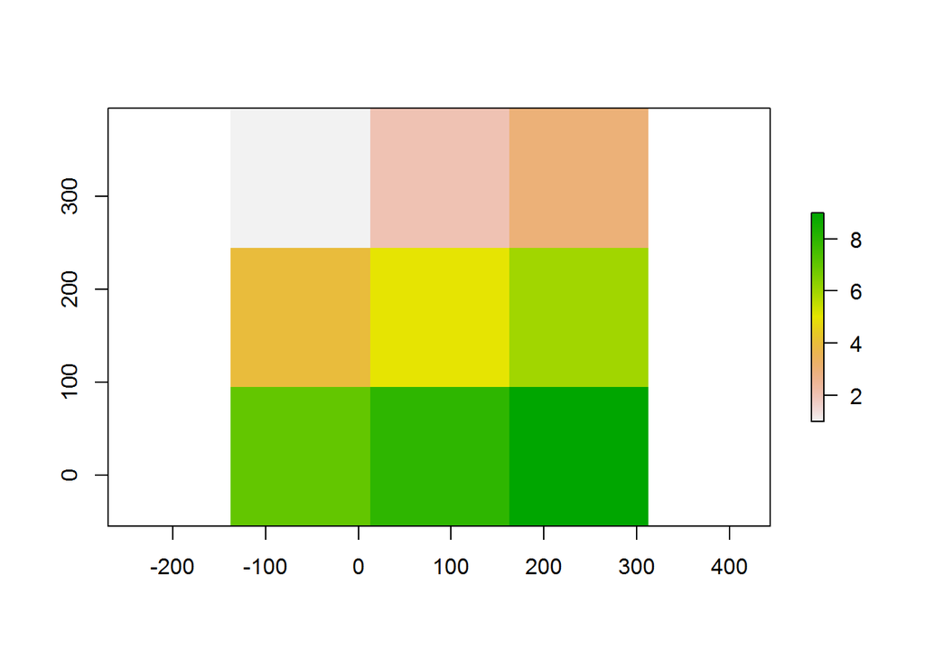

```r
plot(adj_seden[[2]]) #Plot grid used
```

```r
# Using multi-patches movement and median distance travelled
adj_patches<-traj2adj(patches, res=quant(patches, p=0.5)) #Grid size based on median
dim(adj_patches[[1]]) # Size of the adjacency matrix
```

```
## [1] 463 463
```

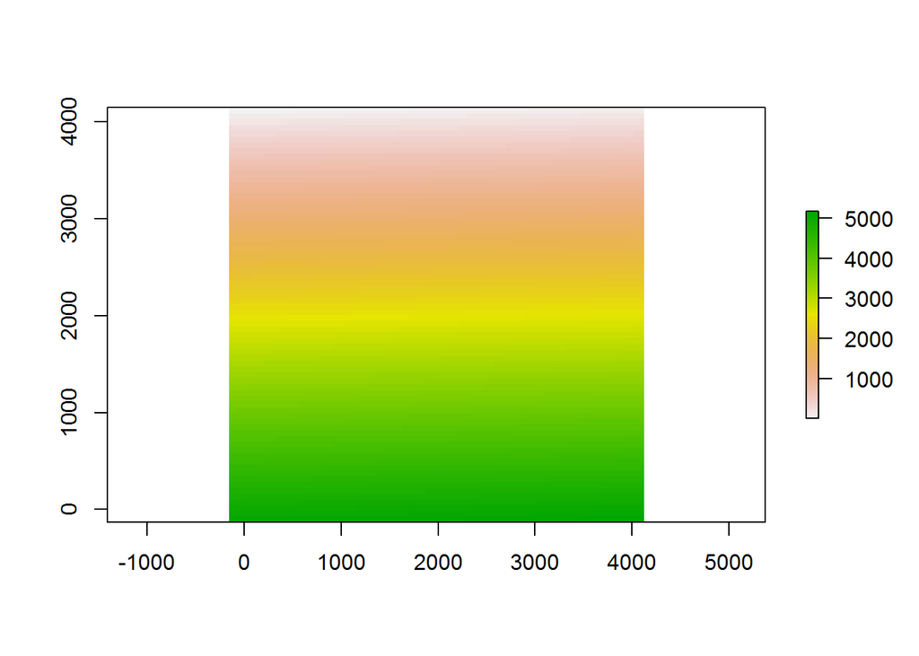

```r
plot(adj_patches[[2]]) #Plot grid used
```

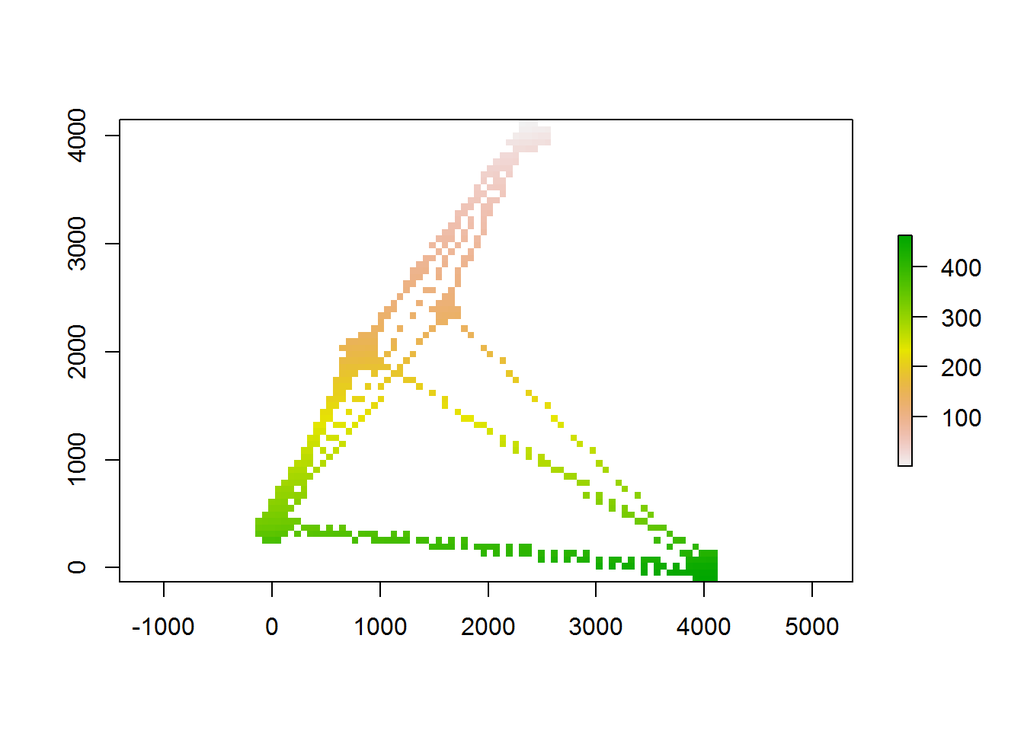

```r
plot(adj_patches[[3]]) #Plot occupied pixels
```

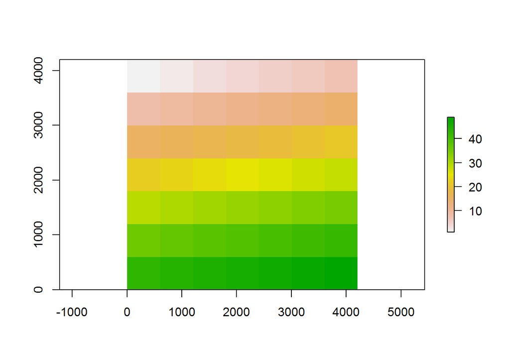

```r
# Using user defined grid
ras<-raster(nrows=10, ncols=10, xmn=0, ymn=0, xmx=6000, ymx=6000)
adj_patches2<-traj2adj(patches, res=quant(patches, p=0.5), grid=ras) #Grid size based on median
plot(adj_patches2[[2]]) #Crop version of the grid created
```